# Analysis of whitefly survival after 5 days

Marc Galland

2016-09-27

# 1 Setup

## 1.1 Knitr options

## 1.2 Load libraries and set current working directory

```r
library(reshape2)
library(plyr)
library(dplyr)
library(Hmisc)
library(knitr)
library(lme4)
library(bbmle)
library(formula.tools)
library(gridExtra)
```

## 1.3 setup directories

```r
inputdata = params$data

# creates result directory and emtpy files present if they already exists
resdir = "results"
dir.create(resdir,showWarnings = F)
unlink(x = dir(resdir,full.names = T),recursive = T)
```

## 1.4 data import + show first lines of the table

```r
wf = read.table(file = inputdata,header = T,sep = "\t",na.strings = "NA",stringsAsFactors=F)
```

# 2 Data wrangling

## 2.1 Creation of a whitefly % of survival melted dataframe

```r
m_wf = melt(data = wf,id.vars = c("accession"),value.name = "percentage",measure.vars = c("percentage"),na.rm = T) #melting from wide to long format
m_wf$variable = NULL
```

## 2.2 Add information on species

```r
accession2species = read.delim(params$species,header = T,sep = "\t",stringsAsFactors=F)
m_wf = dplyr::left_join(x = m_wf,y = accession2species)
```

## 2.3 Calculate the median survival value per accession to order boxplots

It also writes a table of the results

```r
# make a dataframe grouped by accession using dplyr package
df = dplyr::group_by(m_wf,accession)
# calculate median per accession to sort the accessions in increasing wf survival order
df = dplyr::summarise(df,median = median(percentage,na.rm = T))
# sort by increasing median values --> useful for plotting
df = dplyr::arrange(df,median)
df = droplevels.data.frame(df)
ordered_accessions = as.character(df$accession)
# write table
write.table(df,file = file.path(resdir,"median_survival.txt"),sep="\t",quote = F,row.names = F)
```

# 3 Boxplots

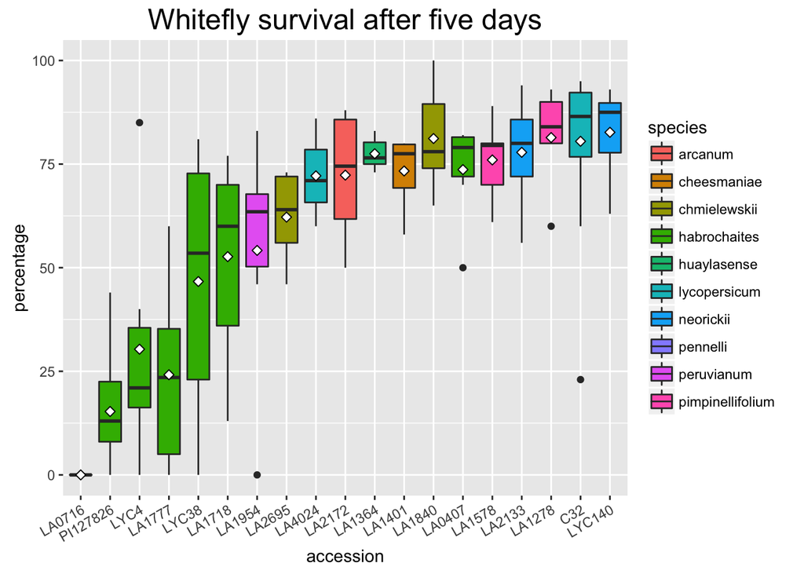

# 4 Generalized Linear Mixed Models

## 4.1 Taken from Yipeng’s past analysis:

The surviving rate of whiteflies in each cage is the result of accession (genotype) effect, block (environment) effect, plant effect (individual variation) and unknown random factors’ effects. Since our object is to use surviving rate of whiteflies in each accession to represent the pest resistance level of corresponding accession, it is better to exclude the influences of the effects of block, plant and cage.

Generalized linear mixed models (GLMMs) were used to analysis the effects of accession, block, plant and cage on the surviving rate. GLMMs are an extension of linear mixed models to allow response variable from different distribution. In linear mixed model, if a treatment affects the population mean, it is a fixed factor. If an effect is associated with a sampling procedure (eg. subject, block), it is a random effect. The general form of the model is: y = Xβ + Zγ + ε Where: y is N*1 response variable X is N*p matrix for predictor variable β is p*1 coefficients Z is the N*q design matrix for the q random effects (the random complement to the fixed X) γ is q*1 vector of the random effects (the random complement to the fixed β) ε is N*1 vector of residuals.

q indicates the levels of random effects, in our case we have 5 blocks, thus q is 5. In matrix Z, if the observation i belongs to the block 1 in that column, the cell will be 1, 0 otherwise. Now we have 2 parameters, γ and β, to estimate. Since we think random effects don’t change the population mean, we assume random γ follows normal distribution N(0, G), and G is the variance-covariance matrix of random effects. Then only β need to be estimated. If y follows normal distribution, linear mixed model could be used, as xi increase 1, y increase βi. However, this is not the case if y is not normal distribution. In GLMMs, we must use link function to link binomial distribution y response variable and linear model. Briefly speaking, it just like using link function to transform y response variable to normal distribution. In binomial GLMMs, loge(p/(1-p)), where p is the probability for live or dead, or loge(live/dead), are commonly used. Thus in binomial GLMMs, the mathematical form is: loge(p/(1-p)) = Xβ + Zγ + ε Restricted maximum likelihood (REML) method is used to estimate β. (above mathematical explanation of GLMMs refer to http://www.ats.ucla.edu/stat/mult_pkg/glmm.htm).

We can then compare models with the deviance (lack of fit) and a Wald-test / Chi2 test

## 4.2 First we fit multiple logistic regression models

```r
# remove missing values
# convert cage to factor
# Calculate a probability to die for each observation
wf = na.omit(wf)
wf$cage = as.factor(wf$cage)
wf$plant = as.factor(wf$plant)

# Remove LA0716
wf = dplyr::filter(.data = wf,accession != "LA0716")

# Fit models
# dead / total - dead
fit1 = glm(cbind(dead,total-dead) ~ 1,data = wf,family = binomial(link = logit)) # intercept only model
fit2 = glm(cbind(dead,total-dead) ~ 1 + accession, data=wf, family = binomial(link = logit)) # model with accession
fit3 = glmer(cbind(dead,total-dead) ~ 1 + accession + (1|accession/plant),data = wf,family=binomial(link = logit)) # random plant effects
fit4 = glmer(cbind(dead,total-dead) ~ 1 + accession + (1|accession/plant/cage),data = wf,family=binomial(link = logit)) # random plant/cage effects
```

## 4.3 Compare models (Deviance and AIC plots)

AIC is an information criteria. It can be compared across different models. A minimal AIC value should be looked for.

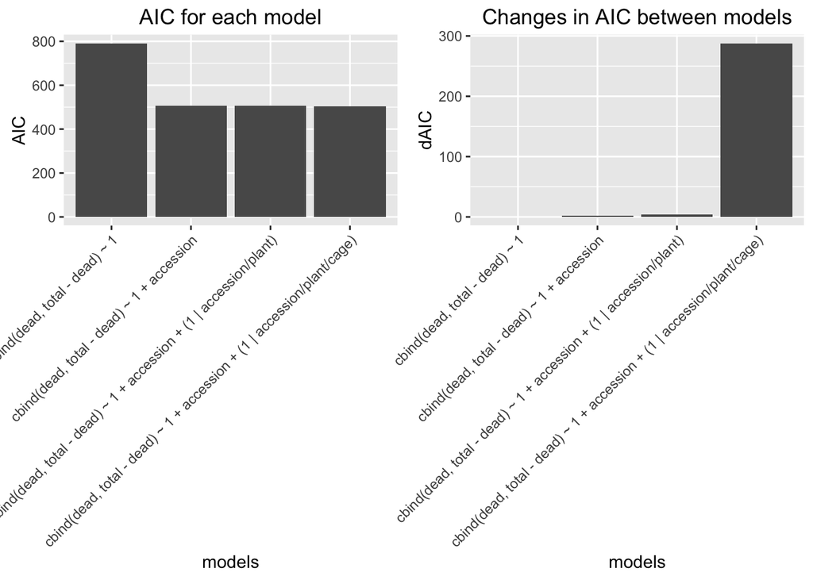

```r
# put all models in a list
fits_no_mixed = list(fit1,fit2)
fits_mixed = list(fit3,fit4)

# gather deviances and plot
deviances = c(deviance(fit1),deviance(fit2),deviance(fit3),deviance(fit4))

# plot AICs and dAICs (differences between AICs)
AICs = cbind.data.frame(
  models = sapply(c(fits_no_mixed,fits_mixed),function(x) {deparse(formula(x))}),
  AIC = sapply(c(fits_no_mixed,fits_mixed),function(x) AIC(x)),
  dAIC = as.vector(bbmle::AICtab(fit1,fit2,fit3,fit4)$dAIC)
  )
plotAIC = ggplot(AICs,aes(models,AIC)) +
  geom_bar(stat="identity") +
  theme(axis.text.x = element_text(angle=45,hjust=1)) +
  ggtitle("AIC for each model")

plotdAIC = ggplot(AICs,aes(models,dAIC)) +
  geom_bar(stat="identity") +
  theme(axis.text.x = element_text(angle=45,hjust=1)) +
  ggtitle("Changes in AIC between models")

grid.arrange(plotAIC,plotdAIC,ncol=2)
```

## 4.4 Compare models with ANOVA

Here I have a problem. Indeed fit1 and fit2 are obtained using a Generalized Linear Model (logit) **without** random effects. In contrast, fit3 and fit4 are obtained using a Generalized Linear Model (logit) **with** random effects. Thus, I cannot get a p-value to compare fit2 and fit3!!

```r
# Model comparison with Likelihood Ratio Test
anova(fit1,fit2,test = "LRT") # intercept only compared to accession model
```

```
## Analysis of Deviance Table
##
## Model 1: cbind(dead, total - dead) ~ 1
## Model 2: cbind(dead, total - dead) ~ 1 + accession
##   Resid. Df Resid. Dev Df Deviance  Pr(>Chi)
## 1       119     502.97
## 2       102     183.73 17   319.23 < 2.2e-16 ***
## ---
## Signif. codes:  0 '***' 0.001 '**' 0.01 '*' 0.05 '.' 0.1 ' ' 1
```

```r
anova(fit2,fit3,test = "LRT") # accession only compared to accession + random effect of the plant
```

```
## Analysis of Deviance Table
##
## Model: binomial, link: logit
##
## Response: cbind(dead, total - dead)
##
## Terms added sequentially (first to last)
##
##
##           Df Deviance Resid. Df Resid. Dev  Pr(>Chi)
## NULL                        119     502.97
## accession 17   319.23       102     183.73 < 2.2e-16 ***
## ---
## Signif. codes:  0 '***' 0.001 '**' 0.01 '*' 0.05 '.' 0.1 ' ' 1
```

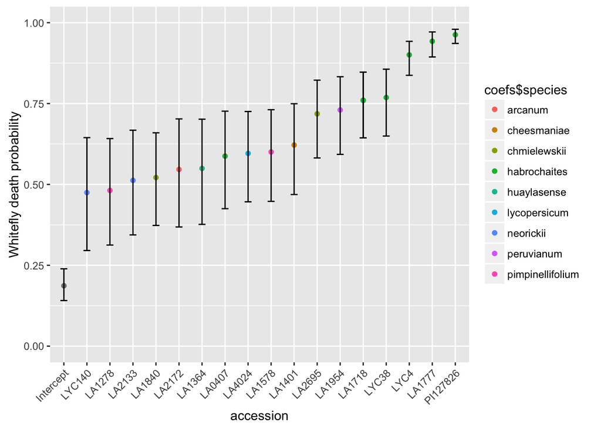

```r
# extract coefficients
coefs = as.data.frame(summary(fit2)$coefficients)
colnames(coefs)=c("coeff","stderr","zval","pval")
coefs$accession = sub("^accession",replacement = "",x = row.names(coefs))
coefs$accession[1] = "Intercept"

# convert coefficients to probabilities (exp(B0 + Bi*Xi=1)/[1+exp(B0 + Bi*Xi=1)]
coefs$prob = sapply(coefs$coeff,function(x) {plogis(x)})

# add confidence interval limits to the coefs (95% confidence)
coefs$lower = sapply(confint(fit2)[,1],function(x) {plogis(x)})
coefs$upper = sapply(confint(fit2)[,2],function(x) {plogis(x)})

# add species
coefs = dplyr::left_join(coefs,accession2species)

# plot by increasing probability to die
coefs = coefs[order(coefs$prob),]
coefs$accession = factor(coefs$accession,levels = coefs$accession)
probas = ggplot(coefs,aes(accession,prob)) +
  geom_point(aes(accession,prob,colour=coefs$species)) +
  geom_errorbar(ymin = coefs$lower,ymax=coefs$upper,width=0.3) +
  theme(axis.text.x = element_text(angle=45,hjust=1)) +
  labs(y = "Whitefly death probability") +
  scale_y_continuous(limits=c(0,1))
print(probas)
```

```r
# save plot into a file
ggsave(filename = file.path(resdir,"probability2die.png"),plot = probas,width=10,height=5,dpi = 400)
```

[output not shown]